# Text mining

Działanie oraz zastosowanie

Adrian Pilarczyk

Proces pozyskiwania wartościowych informacji i wiedzy z dużych ilości nieustrukturyzowanych tekstów. Używa różnych technik analitycznych, takich jak przetwarzanie języka naturalnego, analiza sentymentów, ekstrakcja informacji i klastrowanie, aby identyfikować wzorce, trendy i relacje w danych tekstowych.

Można go używać do automatycznego podsumowywania dokumentów, klasyfikowania treści, identyfikowania trendów.

Dzięki text mining, organizacje mogą przetwarzać i analizować duże zbiory danych tekstowych, co pozwala na szybsze podejmowanie decyzji, lepsze zrozumienie rynku i klientów, a także identyfikację nowych możliwości biznesowych i obszarów ryzyka.

Przejdźmy do przykładów, które pokazują nam zastosowanie text mining.

Wprowadzenie zbioru danych, który zawiera częstość występowania unikalnych słów w dokumentach:

```r
data("AssociatedPress")
AssociatedPress
```

```
## <<DocumentTermMatrix (documents: 2246, terms: 10473)>>
## Non-/sparse entries: 302031/23220327
## Sparsity           : 99%
## Maximal term length: 18
## Weighting          : term frequency (tf)
```

Aby rozpocząć eksploracje tematu, zaczniemy od modelu LDA. Model ten znajduje mieszanine słów powiazaną z tematem, a także określa temat powiązany z podanymi słowami. Istnieje wiele implementacji tego algoryrtmu.

Zaimplementowanie pierwszego modelu LDA, ustawiając k = 2, aby utworzyć dwutematyczny model LDA:

```r
ap_lda <- LDA(AssociatedPress, k = 2, control = list(seed = 1234))
ap_lda
```

```
## A LDA_VEM topic model with 2 topics.
```

Następnie porządkujemy obiekty modelu. Pakiet tidytext udostępnia tę metodę wyodrębniania prawdopodobieństw dla poszczególnych tematów i słów, zwaną $\deta$ z modelu:

```r
ap_topics <- tidy(ap_lda, matrix = "beta")
ap_topics
```

| topic | term | beta |
| --- | --- | --- |
| 1 | aaron | 1.686917e-12 |
| 2 | aaron | 3.895941e-05 |
| 1 | abandon | 2.654910e-05 |
| 2 | abandon | 3.990786e-05 |
| 1 | abandoned | 1.390663e-04 |
| 2 | abandoned | 5.876946e-05 |
| 1 | abandoning | 2.454843e-33 |
| 2 | abandoning | 2.337565e-05 |
| 1 | abbott | 2.130484e-06 |
| 2 | abbott | 2.968045e-05 |

[output cut: 9990 more lines]

Dla każdej kombinacji model oblicza prawdopodobieństwo wygenerowania tego obiektu na podstawie wybranego tematu. Na przykład termin „aaron” ma $1,68*10^{-12}$ prawdopodobieństwo wygenerowania z tematu 1, ale $3,89*10^{−5}$ prawdopodobieństwo wygenerowania z tematu 2.

Jednak z takiej listy możemy mało co wyczytać. Stwórzmy wykresy pokazujące 10 najliczniejszych słów z tematu 1 i 2:

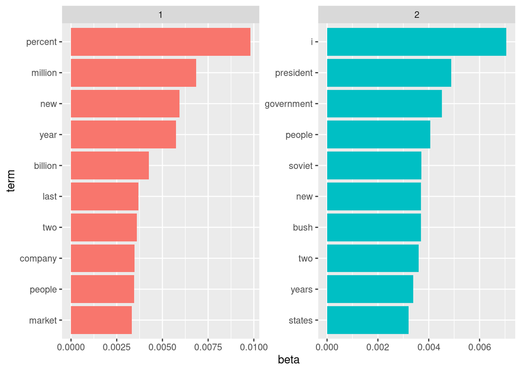

```r
ap_top_terms <- ap_topics %>%
  group_by(topic) %>%
  slice_max(beta, n = 10) %>%
  ungroup() %>%
  arrange(topic, -beta)

ap_top_terms %>%
  mutate(term = reorder_within(term, beta, topic)) %>%
  ggplot(aes(beta, term, fill = factor(topic))) +
  geom_col(show.legend = FALSE) +
  facet_wrap(~ topic, scales = "free") +
  scale_y_reordered()
```

Ta wizualizacja pozwala nam zrozumieć dwa tematy wyodrębnione z artykułów. Najpopularniejsze słowa w temacie 1 sugerują nam, że może on reprezentować wiadomości biznesowe lub finansowe. Najczęstsze słowa w temacie 2 sugerują nam, że ten temat reprezentuje wiadomości polityczne.

Ważną obserwacją dotyczącą słów w każdym temacie jest to, że niektóre słowa, takie jak „nowy” i „ludzie”, są wspólne w obu tematach. Jest to zaleta modelowania tematów w porównaniu z metodami „twardego grupowania”: tematy używane w języku potocznym mogą w pewnym stopniu pokrywać się pod względem słów.

Kiedy “posprzątamy” nasz model pod warunkiem współczynnika $\gamma$, dostaniemy model, który pokazuje procent danego tematu w konkretnym dokumencie:

```r
ap_documents <- tidy(ap_lda, matrix = "gamma")
ap_documents
```

| document | topic | gamma |
| --- | --- | --- |
| 1 | 1 | 0.2480616686 |
| 2 | 1 | 0.3615485445 |
| 3 | 1 | 0.5265844180 |
| 4 | 1 | 0.3566530023 |
| 5 | 1 | 0.1812766762 |
| 6 | 1 | 0.0005883388 |
| 7 | 1 | 0.7734215655 |
| 8 | 1 | 0.0044516994 |
| 9 | 1 | 0.9669915139 |
| 10 | 1 | 0.1468904793 |

[output cut: 4482 more lines]

Możemy zauważyć, że w dokumencie 6 tematem przewodnim jest temat 2 w 99% procentach. Wyłonimy z niego najpopularniejsze słowa, aby ustalić temat artykułu:

```r
tidy(AssociatedPress) %>%
  filter(document == 6) %>%
  arrange(desc(count))
```

| document | term | count |
| --- | --- | --- |
| 6 | noriega | 16 |
| 6 | panama | 12 |
| 6 | jackson | 6 |
| 6 | powell | 6 |
| 6 | administration | 5 |
| 6 | economic | 5 |
| 6 | general | 5 |
| 6 | i | 5 |
| 6 | panamanian | 5 |
| 6 | american | 4 |

[output cut: 277 more lines]

Sądząc po najpopularniejszych słowach, wydaje się, że jest to artykuł o stosunkach rządu amerykańskiego. Algorytm słusznie umieścił go w temacie 2 (jako wiadomości polityczne/krajowe).

A kto powiedział, że słowa nie mają znaczenia/emocji? Istnieje wiele metod i słowników służących do oceny opinii lub emocji w tekście. Zajmiemy się jednym z nich. Leksykon $nrc$ kategoryzuje słowa w sposób binarny („tak” / „nie”) z kategorii pozytywne, negatywne, złość, entuzjastyczne, wstręt, strach, radość, smutek, zaskoczenie oraz zaufanie. Adnotacje zostały wykonane ręcznie poprzez crowdsourcing.

```r
get_sentiments("nrc")
```

| word | sentiment |
| --- | --- |
| abacus | trust |
| abandon | fear |
| abandon | negative |
| abandon | sadness |
| abandoned | anger |
| abandoned | fear |
| abandoned | negative |
| abandoned | sadness |
| abandonment | anger |
| abandonment | fear |

[output cut: 9990 more lines]

Użyjemy tego leksykonu do zdefiniowa, czy dana książka zawiera pozytywne słowa. Skupimy się tutaj na przykładzie książki $Emma$ autorki Jane Austen. Najpierw każdą książke z zbioru danych $janeaustenr$ rozbijemy na pojedyńcze, poukładane słowa:

```r
tidy_books <- austen_books() %>%
  group_by(book) %>%
  mutate(
    linenumber = row_number(),
    chapter = cumsum(str_detect(text,
                                regex("^chapter [\\divxlc]",
                                      ignore_case = TRUE)))) %>%
  ungroup() %>%
  unnest_tokens(word, text)
```

Następnie nakłady filtr, który pokaże nam najczęściej występujące “pozytywne” słowa w wybranej przez nas książce:

```r
nrc_positive <- get_sentiments("nrc") %>%
  filter(sentiment == "positive")

tidy_books %>%
  filter(book == "Emma") %>%
  inner_join(nrc_positive) %>%
  count(word, sort = TRUE)
```

| word | n |
| --- | --- |
| good | 359 |
| dear | 241 |
| frank | 200 |
| friend | 166 |
| hope | 143 |
| happy | 125 |
| love | 117 |
| word | 94 |
| deal | 92 |
| found | 92 |

[output cut: 856 more lines]

Ostatecznie pokażemy wykres z ilością słów w podanej książce dla odpowiedniej kategorii emocji:

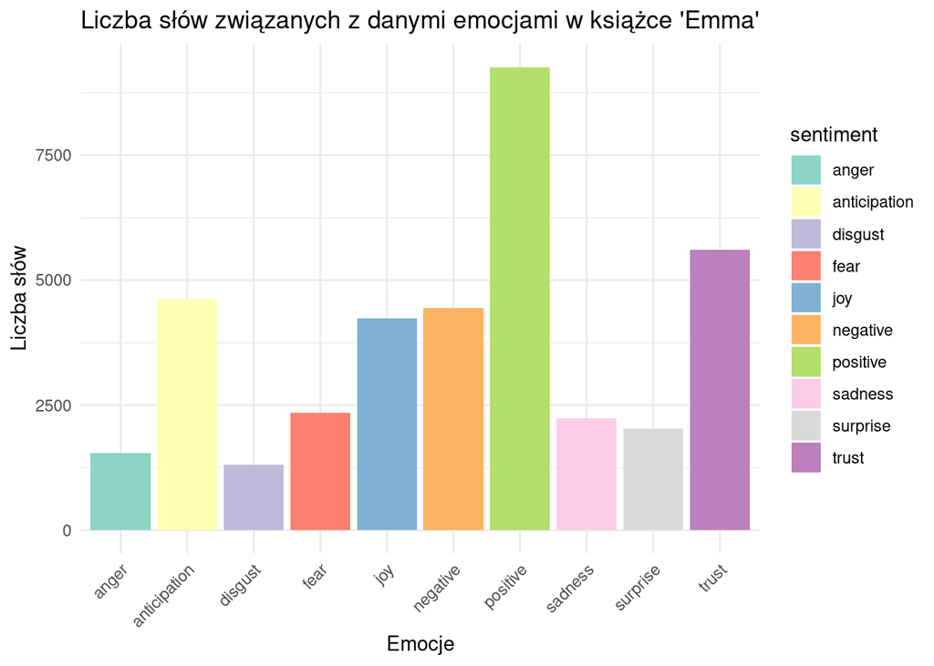

```r
nrc_sentiments <- get_sentiments("nrc")

emma_sentiments <- tidy_books %>%
  filter(book == "Emma") %>%
  inner_join(nrc_sentiments, by = "word", relationship = "many-to-many") %>%
  count(sentiment, sort = TRUE)

ggplot(emma_sentiments, aes(x = sentiment, y = n, fill = sentiment)) +
  geom_bar(stat = "identity") +
  theme_minimal() +
  labs(title = "Liczba słów związanych z danymi emocjami w książce 'Emma'",
       x = "Emocje",
       y = "Liczba słów") +
  theme(axis.text.x = element_text(angle = 45, hjust = 1)) +
  scale_fill_brewer(palette = "Set3")
```